# Introduction to StatComp20039

Xinyi C

2020-12-20

## Overview

**StatComp20039** is a simple R package developed to deal with data dimension reduction of matrix. Linear dimension reduction methods and nonlinear dimensionality reduction method are considered.The linear dimension reduction method can use two functions, namely, *pca* and *lda* .The nonlinear dimensionality reduction method can be used for *lle*. The R package ‘FNN’ can be used to find k-nearest neighbors of samples.

## Data dimensionality reduction *pca*

PCA (principal component analysis) algorithm has a strong application in image recognition and dimensionality reduction of high-dimensional data. The algorithm selects the feature vector with larger eigenvalue to transform the original data linearly. It can not only remove the useless noise,but also reduce the amount of calculation.

The source R code for *pca* is as follows:

```r
function(X){
  x0=apply(X,1,mean)
  sigma=(X-x0)%*%t(X-x0)
  svdw=eigen(sigma)
  percentage2=function(X,per){
    arraysum=sum(X)
    m=length(X)
    temarray=0
    num=0
    for (i in 1:m) {
      temarray=temarray+X[i]
      num=num+1
      if(temarray>=arraysum*per)break
    }
    return(num)
  }
  d=percentage2(svdw$values,per=0.90)
  w1=svdw$vectors
  W=w1[,(1:d)]
  Y=t(W)%*%(X-x0)
  reY=W%*%Y+x0
  return(list(Y=Y,reY=reY,x0=x0,num=d))
}
```

The following is an example of dimension reduction using *pca* function.The R code for *pca* is as follows.

```r
set.seed(1234)
options(warn =-1)
library(DT)
library(StatComp20039)
X=matrix(runif(7,min=165,max=180),nrow = 1,ncol = 7)
Y=matrix(runif(7,min=55,max=75),nrow = 1,ncol = 7)
Z=matrix(runif(7,min = 17,max = 20),nrow = 1,ncol = 7)
sigma=c(1:ncol(Z))
Acc = rbind(X,Y,Z)
Acc = round(Acc)
datatable(Acc,rownames = c("Heights","Weights","age"),
colnames = paste("S",sigma))
```

|  | S 1 | S 2 | S 3 | S 4 | S 5 | S 6 | S 7 |
| --- | --- | --- | --- | --- | --- | --- | --- |
| Heights | 167 | 174 | 174 | 174 | 178 | 175 | 165 |
| Weights | 60 | 68 | 65 | 69 | 66 | 61 | 73 |
| age | 18 | 20 | 18 | 18 | 18 | 18 | 18 |

```r
library(StatComp20039)
X=matrix(runif(7,min=165,max=180),nrow = 1,ncol = 7)
Y=matrix(runif(7,min=55,max=75),nrow = 1,ncol = 7)
Z=matrix(runif(7,min = 17,max = 20),nrow = 1,ncol = 7)
sigma=c(1:ncol(Z))
sigma=c(1:ncol(Z))
Acc = rbind(X,Y,Z)
Acc = round(Acc)
rY=StatComp20039::pca(Acc)$Y
rY=round(rY,3)
datatable(rY,rownames = paste("PC",(1:nrow(rY))),
colnames = paste("S",sigma))
```

|  | S 1 | S 2 | S 3 | S 4 | S 5 | S 6 | S 7 |
| --- | --- | --- | --- | --- | --- | --- | --- |
| PC 1 | -8.435 | 2.354 | -4.579 | -0.17 | 4.545 | -1.066 | 7.351 |
| PC 2 | 4.745 | -7.473 | -3.36 | -4.139 | 3.526 | 2.822 | 3.878 |

The above results show an dimension reduction results of linear data.

## Data dimensionality reduction *lda*

The basic idea is to project the high-dimensional pattern samples into the optimal discriminant vector space to extract classification information and compress the dimension of feature space. After projection, the pattern samples are guaranteed to have the maximum inter class distance and the minimum intra class distance in the new subspace, that is, the pattern has the best separability in this space.

The source R code for *lda* is as follows:

```r
function(X,Y,d){
  m1=nrow(X)
  m2=nrow(Y)
  m3=ncol(X)
  m4=ncol(Y)
  XY=rbind(X,Y)
  u=apply(XY,2,mean)
  u1=apply(X,2,mean)
  u2=apply(Y,2,mean)
  sb=m1*((u1-u)%*%t(u1-u))+m2*((u2-u)%*%t(u2-u))
  sw1=matrix(0,nrow = m3,ncol = m3)
  sw2=matrix(0,nrow = m4,ncol = m4)
  for (i in 1:m1) {
    sw1=as.matrix((u1-X[i,]))%*%t(as.matrix((u1-X[i,])))+sw1
  }
  for (j in 1:m2) {
    sw2=as.matrix((u2-Y[j,]))%*%t(as.matrix((u2-Y[j,])))+sw2
  }
  sw=sw1+sw2
  w=solve(sw)%*%sb
  wl=eigen(w)
  M=wl$vectors
  w0=M[,c(1:d)]
  X1=X%*%w0
  Y1=Y%*%w0
  return(list(x1=X1,y1=Y1,vectors=M))
}
```

The above R code *lda* is used to reduce the dimension of the second kind of data matrix.The specific examples are as follows:

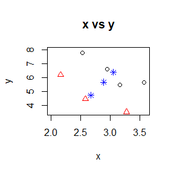

```r
library(StatComp20039)
X=matrix(c(2.95,6.63,2.53,7.79,3.57,5.65,3.16,5.47),nrow = 4,ncol = 2,byrow = TRUE)
Y=matrix(c(2.58,4.46,2.16,6.22,3.27,3.52),nrow = 3,ncol = 2,byrow = TRUE)
ex=apply(X,2,mean)
ey=apply(Y,2,mean)
E=apply(rbind(X,Y),2,mean)
ee=rbind(ex,ey,E)
par(mfrow=c(1,1))
plot(X[,1],X[,2], pch = 1, xlab = "x", ylab = "y", main = "x vs y",xlim = c(2,3.6),ylim = c(3.5,8))
points(Y[,1],Y[,2],pch = 2,col="red")
points(ee[,1],ee[,2],pch=8,col="blue")
```

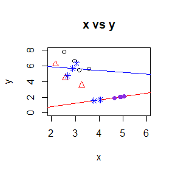

```r
par(mfrow=c(1,1))
m=StatComp20039::lda(X=X,Y=Y,d=1)$vectors
m1=m[,1]
m2=m[,2]
k1=m1[2]/m1[1]
b1=0
k2=m2[2]/m2[1]
b2=E[2]-k2*E[1]
plot(X[,1],X[,2], pch = 1, xlab = "x", ylab = "y", main = "x vs y",xlim = c(2,6),ylim = c(0,8))
points(Y[,1],Y[,2],pch = 2,col="red")
points(ee[,1],ee[,2],pch=8,col="blue")
abline(0,k1,col="red")
abline(b2,k2,col="blue")
newx1=length(nrow(X))
newy1=length(nrow(X))
newx2=length(nrow(Y))
newy2=length(nrow(Y))
for (i in 1:4) {
  tem=X[i,]
  newx1[i]=(tem[1]+tem[2]*k1)/(k1*k1+1)
  newy1[i]=k1*newx1[i]
}
for (j in 1:3) {
  temp=Y[j,]
  newx2[j]=(temp[1]+k1*temp[2])/(k1*k1+1)
  newy2[j]=k1*newx2[j]
}
points(newx1,newy1,type = "p",pch=19,col="blueviolet")
points(newx2,newy2,type = "p",col="blue",pch=8)
```

## Data dimensionality reduction *lle*

The source R code for *lle* is as follows:

```r
function(X,d,k){
  X=t(X)
  l=knn.index(X,k)
  n=nrow(X)
  w=matrix(nrow=n,ncol=k)
  wx=matrix(0,nrow=n,ncol = n)
  for (i in 1:n) {
    z=X[c(l[i,]),]
    lk=apply(-z,1,FUN = "+",X[i,])
    q=t(lk)%*%lk
    lambda=5
    em=solve(q+lambda*diag(k))
    w[i,]=apply(em,1,sum)/sum(em)
    sh=l[i,]
    for (j in 1:k) {
      wx[i,sh[j]]=w[i,j]
    }
  }
  M=t(diag(n)-wx)%*%(diag(n)-wx)
  NM=eigen(M)$vectors
  D=d+1
  Y=t(NM[,(2:D)])*sqrt(n)
  return(Y)
}
```

The above R code *lle* is a recently proposed nonlinear dimensionality reduction method, which is different from the above two linear dimensionality reduction methods. It keeps the original topological structure of the reduced data.The specific examples are as follows:

```r
library(DT)
library(StatComp20039)
X=matrix(runif(7,min=165,max=180),nrow = 1,ncol = 7)
Y=matrix(runif(7,min=55,max=75),nrow = 1,ncol = 7)
Z=matrix(runif(7,min = 17,max = 20),nrow = 1,ncol = 7)
sigma=c(1:ncol(Z))
Acc = rbind(X,Y,Z)
Acc = round(Acc)
datatable(Acc,rownames = c("Heights","Weights","age"),
colnames = paste("S",sigma))
```

|  | S 1 | S 2 | S 3 | S 4 | S 5 | S 6 | S 7 |
| --- | --- | --- | --- | --- | --- | --- | --- |
| Heights | 170 | 174 | 170 | 173 | 175 | 172 | 169 |
| Weights | 70 | 56 | 61 | 69 | 65 | 58 | 65 |
| age | 18 | 19 | 18 | 20 | 20 | 17 | 18 |

```r
options(warn =-1)
library(DT)
library(StatComp20039)
X=matrix(runif(7,min=165,max=180),nrow = 1,ncol = 7)
Y=matrix(runif(7,min=55,max=75),nrow = 1,ncol = 7)
Z=matrix(runif(7,min = 17,max = 20),nrow = 1,ncol = 7)
sigma=c(1:ncol(Z))
Acc = rbind(X,Y,Z)
Acc = round(Acc)
rY=StatComp20039::lle(Acc,d=1,k=2)
rY=round(rY,3)
datatable(rY,rownames = paste("PC",(1:nrow(rY))),
colnames = paste("S",sigma))
```

|  | S 1 | S 2 | S 3 | S 4 | S 5 | S 6 | S 7 |
| --- | --- | --- | --- | --- | --- | --- | --- |
| PC 1 | -0.031 | -1.601 | -0.465 | 1.901 | 0.631 | -0.458 | 0.023 |

The above results show an dimension reduction results of nonlinear data.